# MMHP Example - Email Data

In this notebook we fit the proposed MMHP model to email interactions between two users. We analyse model fit and show this proposed model is well suited to modeling the sporadic and bursty nature of email interactions. We also fit the alternative models from the literature and show they are not able to describe the latent structure present in this data.

```r
sample_times = readRDS("C:/Users/owenw/Documents/MMHP_Paper/data/time.RDS")
time_vec = sample_times
termination_time = 122
diff_times = diff(c(0,time_vec,termination_time))
```

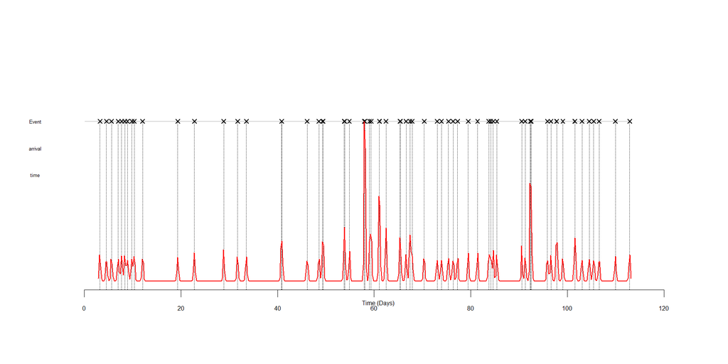

```r
#par(mfrow=c(1,2))
x_lim = 122
current_event_time = time_vec
plot(0.5,0,xlim=c(-0.2,x_lim),ylim=c(0.7,1.1), type="n",
     xlab="",ylab="",xaxt="n",yaxt="n",cex.lab=.5,bty="n")
#title("(a)",cex.main=.5,line = -0.75)
title(xlab = "Time (Days)", cex.lab=0.5, line = 0.25)
axis(2,at=c(1,2),labels=FALSE,cex.lab=.5,las=2,lwd=0,lwd.ticks=0)
axis(1,at=seq(0,120,20),labels=FALSE,cex.lab=.2,las=1,lwd=.3,lwd.ticks=0.5)
text(seq(0,120,20), y=0.65, labels=seq(0,120,20), cex=.5, srt=0, xpd=TRUE)

segments(x0=0.1,x1=max(current_event_time),y0=1,col="lightgrey",lwd=1)

# jitter points
#y_jitt <- c(rep(1.5,length(current_event_time)))
#y_jitt <- jitter(y_jitt,factor = 1.5)

points(current_event_time,rep(1,length(current_event_time)),
       pch=4,col="black",cex=0.75,lwd=1)
for(i in 1:length(current_event_time)){
  segments(x0=current_event_time[i],x1=current_event_time[i],
           y0=0.5,y1=1,lty=3,lwd = 0.5)
}
#points(current_event_time,rep(1.5,length(current_event_time)),pch=4,col="black",cex=.5,lwd=1)
#segments(x0=clean_data$observation_change,y0=0.5,y1=1.5,lty=1,col="red") # add observation period

text(-10.1, y=1, labels="Event", cex=.4, srt=0, xpd=TRUE)
text(-10.1, y=.95, labels="arrival", cex=.4, srt=0, xpd=TRUE)
text(-10.1, y=0.9, labels="time", cex=.4, srt=0, xpd=TRUE)

bw.used = 0.1
density.event=density(time_vec, bw=bw.used)
density.event$y=(density.event$y+0.5)/max(density.event$y+0.5)
lines(density.event, col=2)
```

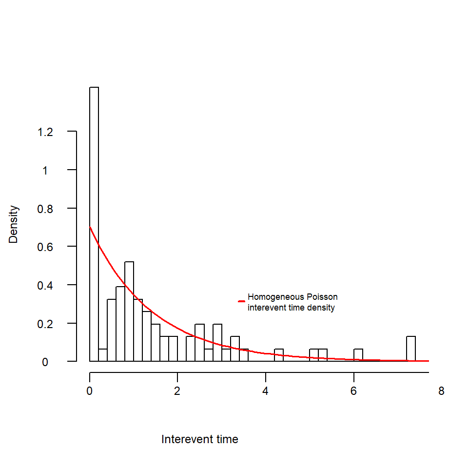

```r
interevent_time_vec = diff(time_vec)
hist(interevent_time_vec,freq=F,breaks=30,
     xlab="",ylab="Density",
     xaxt="n",yaxt="n",
     main="",cex.lab=0.75, bty="o")

#title("(b)",line=-0.5,cex.main=2)
axis(2,at=seq(0,1.2,0.2),labels=FALSE,cex.lab=1,las=2,lwd=1.2,lwd.ticks=1)
axis(1,at=seq(0,8,2),labels=FALSE,cex.lab=1,las=2,lwd=1.2,lwd.ticks=1)
text(-1, y=seq(0,1.2,0.2), labels=seq(0,1.2,0.2), cex=0.75, srt=0, xpd=TRUE)
text(seq(0,8,2), y=-0.15, labels=seq(0,8,2), cex=0.75, srt=0, xpd=TRUE)
text(2.5,-0.4,"Interevent time", cex=0.75, srt=0, xpd=TRUE)




## Plot the density curve for interevent time
# h <- hist(current_event_time[-1]-current_event_time[-length(current_event_time)], plot = FALSE, breaks=10)
# xl <- seq(0, max(h$mids), (max(h$mids))/1000)
# lines(xl, predict(loess(c(1,h$density) ~ c(-0.5,h$mids), span = 1.2), xl), lwd = 3, col="blue")

## Plot the density curve for exponential
exp_lambda_hat <- 1/(mean(interevent_time_vec))
curve(dexp(x, rate=exp_lambda_hat),
      xlim=c(0,8),
      lwd=1.5, col="red", add = TRUE)

legend(3.2,0.4,c("Homogeneous Poisson \ninterevent time density"),
       lty=1,lwd=2,col=c("red"),y.intersp=0.9,x.intersp=0.4,seg.len=0.8,bty="n",cex=.55)
```

This data is both sporadic and bursty, with many events occuring in small time periods, along with longer periods with no interactions.

```r
a = as.matrix(diff_times, nrow = 1, ncol = length(diff_times))

fit_mmhp <- stan("C:/Users/owenw/Documents/MMHP_Paper/lib/New_mmhp_Continuous.stan",
                 data = list(N_til = 1,
                             max_Nm = length(time_vec),
                             Nm = as.array(length(time_vec)),
                             time_matrix= t(a),
                             max_interevent = as.array(max(diff_times))),
                 warmup = 1000,
                 iter = 3500, chains = 4, thin = 5,control = list(adapt_delta=0.9))
```

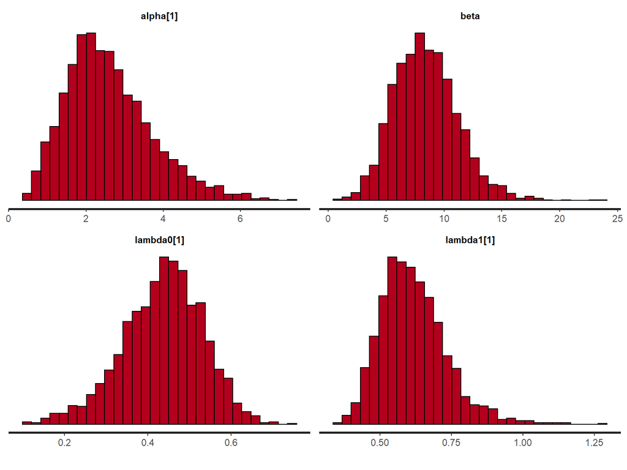

```r
stan_hist(fit_mmhp,pars = c("alpha","beta","lambda0","lambda1"))
```

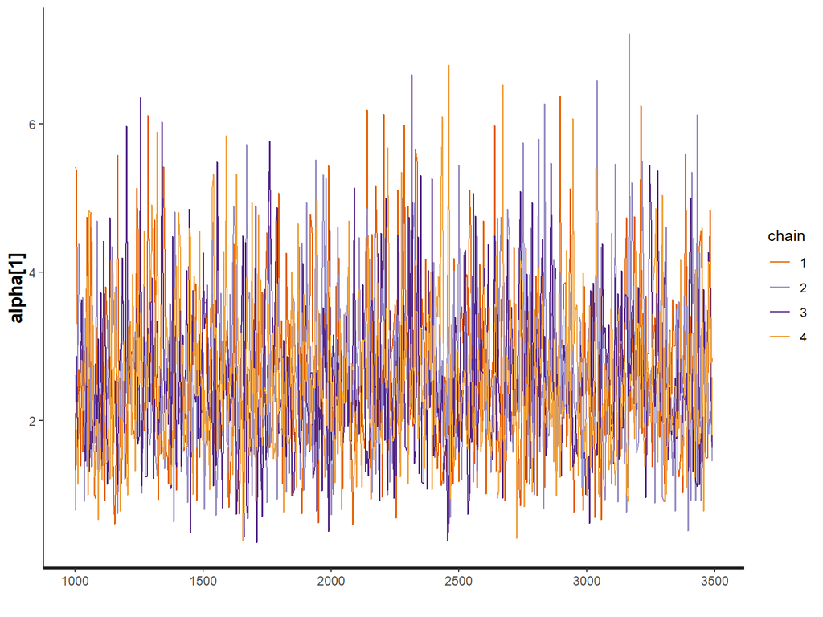

```r
# Traceplots
traceplot(fit_mmhp,pars = "alpha")
```

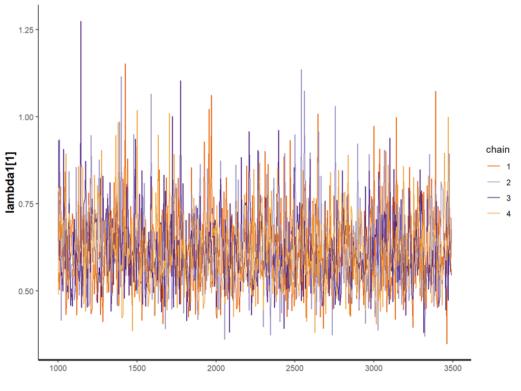

```r
traceplot(fit_mmhp,pars = "lambda1")
```

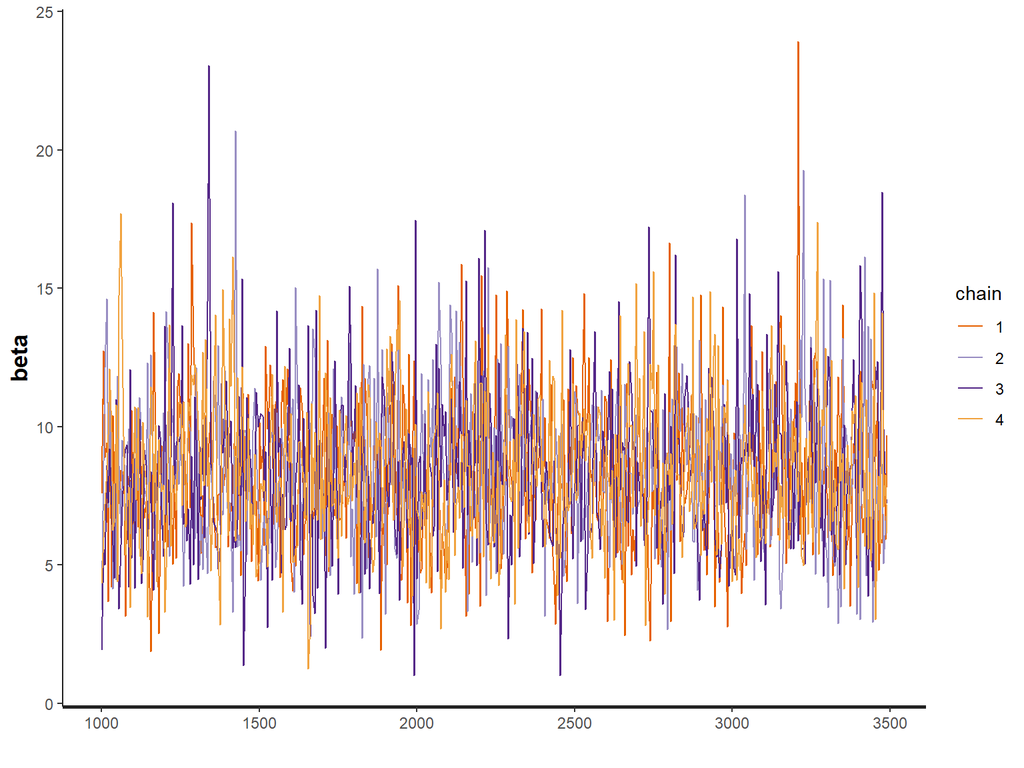

```r
traceplot(fit_mmhp,pars = "beta")
```

We can then infer the latent state. For this pair, this is given below.

```r
sim_mmhp <- rstan::extract(fit_mmhp)
no_segments <- 10000

param <- rep(list(),2000)
delta_vec <- rep(0,2000)
for(current_sim in 1:2000){
  param[[current_sim]] <- list(lambda1=sim_mmhp$lambda1[current_sim],
                               lambda0=sim_mmhp$lambda0[current_sim],
                               alpha=sim_mmhp$alpha[current_sim],
                               beta=sim_mmhp$beta[current_sim],
                               q1=sim_mmhp$q1[current_sim],
                               q2=sim_mmhp$q2[current_sim])
  delta_vec[current_sim] <- sim_mmhp$delta_1[current_sim]
}


time_segment <- seq(0,termination_time,length.out=no_segments)

state_array_list <- matrix(0,nrow=length(time_vec),ncol=2000)
initial_state_list <- matrix(0,nrow=1,ncol=2000)
termination_state_list <- matrix(0,nrow=1,ncol=2000)
interpolation_array_list <- matrix(0,nrow=no_segments,ncol=2000)


# store the results of modified latent trajectory
latent_inter_mod_out <- rep(list(),2000)

source("C:/Users/owenw/Documents/MMHP_Paper/lib/inferLatentMmhp.R")
source("C:/Users/owenw/Documents/MMHP_Paper/lib/Interpolate_Latent_Modified.R")

for(current_sim in 1:2000){

  viterbi_result <- myViterbiWithInitial(events = time_vec, param = param[[current_sim]],termination = termination_time,
                                         initial.p = delta_vec[current_sim] )
  state_array_list[,current_sim] <- viterbi_result$zt_v
  initial_state_list[current_sim] <- viterbi_result$initial_state
  termination_state_list[current_sim] <- viterbi_result$termination_state

  latent_inter <- interpolateLatentTrajectory(params = param[[current_sim]], events = time_vec,
                                              zt = viterbi_result$zt_v,
                                              initial.state = viterbi_result$initial_state,
                                              termination.state = viterbi_result$termination_state,
                                              termination.time = termination_time )

  step_fun_est <- stepfun(latent_inter$x.hat,2-latent_inter$z.hat)
  # this means that interpolation_array is 1 for active and 0 for inactive.
  interpolation_array_list[,current_sim] <- step_fun_est(time_segment)
}

lambda0_mean <- mean(sim_mmhp$lambda0)
lambda1_mean <- mean(sim_mmhp$lambda1)
alpha_mean <- mean(sim_mmhp$alpha)
beta_mean <- mean(sim_mmhp$beta)
q1_mean <- mean(sim_mmhp$q1)
q2_mean <- mean(sim_mmhp$q2)


ztv_mmhp_pair <- t(ifelse(apply(state_array_list,c(1),function(x) sum(x==1)) >1000,1,2))

summary(as.vector(ztv_mmhp_pair))
```

```
##    Min. 1st Qu.  Median    Mean 3rd Qu.    Max.
##   1.000   1.000   1.000   1.423   2.000   2.000
```

We can then view the estimate latent state for the MMHP model.

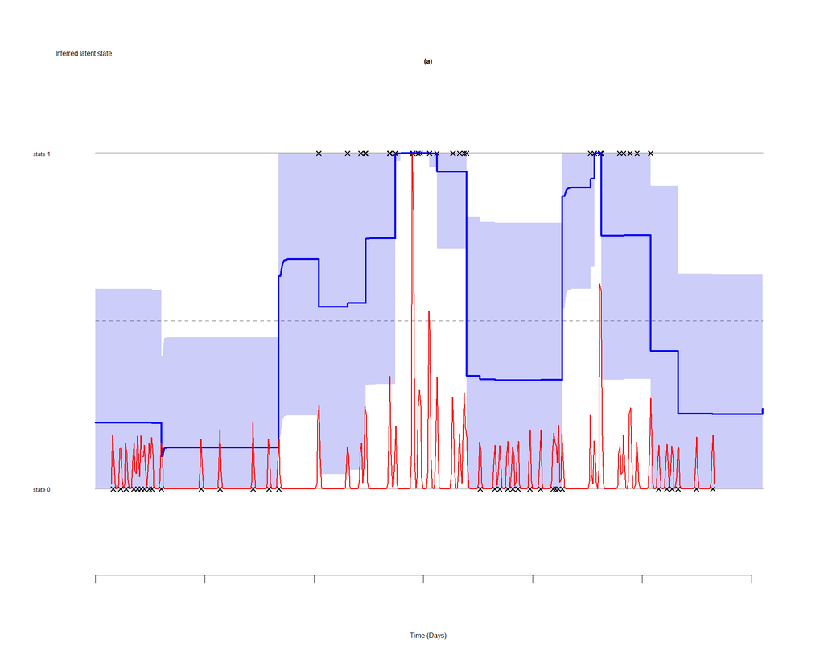

```r
plot(0,0,xlim=c(-0.2,x_lim),ylim=c(-0.2,1.2), type="n",
     xlab="Time (Days)",ylab="",xaxt="n",yaxt="n",cex.lab=0.5,bty="n")
#title("(a) MMPP",line=1,cex.main=2)
axis(2,at=c(1,2),labels=FALSE,cex.lab=0.5,las=2,lwd=0,lwd.ticks=0)
axis(1,at=seq(0,x_lim,20),labels=FALSE,cex.lab=2,las=1,lwd=.3,lwd.ticks=0.5)
text(-9.5, y=c(0,1), labels=paste(c("state","state"),c(0,1)," "), cex=0.4, srt=0, xpd=TRUE)
text(-2, y=1.3, labels="Inferred latent state", cex=0.5, srt=0, xpd=TRUE)
text(seq(0,x_lim,20), y=-0.55, labels=seq(0,x_lim,20), cex=0.75, srt=0, xpd=TRUE)
segments(x0=0,x1=termination_time,y0=1,col="lightgrey",lwd=2)
segments(x0=0,x1=termination_time,y0=0,col="lightgrey",lwd=2)
segments(x0=0,x1=termination_time,y0=0.5,col="darkgrey",lwd=1,lty=2)
#segments(x0=clean_data$observation_change,y0=0,y1=1,col='red')



current_event_time <- time_vec


#prob <- apply(state_array_list_mmpp,1,function(x) sum(x==1)/2000)
points(current_event_time,2-ztv_mmhp_pair,pch=4,col="black",lwd=1,cex=0.75)

## plot interpolated state
time_segment <- seq(0,termination_time,length.out=no_segments)#+delta.x
plot.mean <- apply(interpolation_array_list,1,mean)
plot.sd <- apply(interpolation_array_list,1,sd)
lines(plot.mean~time_segment,type="l",col="blue",lwd=2)
polygon(c(time_segment,rev(time_segment)),
        c(ifelse(plot.mean-plot.sd<0,rep(0,length(plot.mean)),plot.mean-plot.sd),
          rev(ifelse(plot.mean+plot.sd>1,rep(1,length(plot.mean)),plot.mean+plot.sd))),
        col=rgb(0,0,225,alpha=50,maxColorValue=255),border=FALSE)
title("(a)",line=0.25,cex.main=0.5)

# add kde
bw.used = 0.1
density.event=density(time_vec, bw=bw.used)
density.event$y=(density.event$y)/max(density.event$y)
lines(density.event, col=2)
```

We can evaluate how well this model fits by looking at the distribution of the rescaled inter-arrival times.

```r
mmhpCompensator<-function(params=list(lambda0,lambda1,alpha,beta,q1,q2), t, pzt, if.pzt=TRUE){
  lambda0 <- params$lambda0
  lambda1 <- params$lambda1
  alpha <- params$alpha
  beta <- params$beta
  q1 <- params$q1
  q2 <- params$q2
  n <- length(t) - 1
  interevent <- t[-1]-t[-(n+1)]
  if(if.pzt){
    pzt <- mmhpLocalState(params=params, interevent)$pzt
  }

  ##compute compensator for Hawkes process
  Lambda <- rep(0,n)
  A<-0
  Lambda[1]<-lambda0*(interevent[1])
  for(i in 2:n){
    A<-1+exp(-beta*(interevent[i-1]))*A
    Lambda[i]<-lambda1*(interevent[i])+alpha/beta*(1-exp(-beta*interevent[i]))*A
  }

  Lambda_mixed <- Lambda*pzt + lambda0*interevent*(1-pzt)
  return(Lambda_mixed)
}

mmhpLocalState <- function(params=list(lambda0,lambda1,alpha,beta,q1,q2), interevent){
  lambda0 <- params$lambda0
  lambda1 <- params$lambda1
  alpha <- params$alpha
  beta <- params$beta
  q1 <- params$q1
  q2 <- params$q2
  N <- length(interevent)

  pzt <- rep(0,N)
  zt <- rep(0,N)
  r <- rep(0,N)
  intensities <- rep(0,2)
  integrals <- rep(0,2)
  forward <- matrix(0,nrow=N,ncol=2)
  backward <- matrix(0,nrow=N,ncol=2)
  probs_1 <- matrix(0,nrow=N,ncol=2) #Probability vector for transition to state 1 (active state)
  probs_2 <- matrix(0,nrow=N,ncol=2) #Probability vector for transition to state 2 (inactive state)

  probs_1[,1] <- -q1*interevent
  probs_2[,2] <- -q2*interevent
  probs_1[,2] <- log(1-exp(probs_2[,2]))
  probs_2[,1] <- log(1-exp(probs_1[,1]))

  #calculate forward and log_p_z_star => zt*[N]
  forward[1,1] <- log(lambda0) - interevent[1]*lambda1
  forward[1,2] <- log(lambda0) - interevent[1]*lambda0 #calculate forward variables, uniform initial distribution for latent state
  r[1] <- 0

  for(n in 2:N){
    r[n] <- exp(-beta*interevent[n])*(r[n-1]+1)
    a <- max(forward[n-1,] + probs_1[n,])
    forward[n,1] <- a + log(sum(exp(forward[n-1,] + probs_1[n,] - a))) + log(lambda1+alpha*exp(-beta*interevent[n])*(r[n-1]+1)) - interevent[n]*lambda1 +
      alpha/beta*(r[n]-r[n-1]-1)
    a <- max(forward[n-1,] + probs_2[n-1,])
    forward[n,2] <- a + log(sum(exp(forward[n-1,] + probs_2[n,] - a))) + log(lambda0) - interevent[n]*lambda0
  }

  #calculate backward variables
  backward[N,1] <- 0
  backward[N,2] <- 0
  intensities[2] <- lambda0

  for(n in 2:N){
    m <- N-n+1
    intensities[1] <- lambda1 + alpha*exp(-beta*interevent[m+1])*(r[m]+1)
    integrals[2] <- lambda0*interevent[m]
    integrals[1] <- lambda1*interevent[m] - alpha/beta*(r[m+1]-r[m]-1)
    a <-  max(backward[m+1,]+probs_1[m+1,]+log(intensities)-integrals)
    backward[m,1] <- a+log(sum(exp(backward[m+1,]+probs_1[m+1,]+log(intensities)-integrals-a)))
    a <-  max(backward[m+1,]+probs_2[m+1,]+log(intensities)-integrals)
    backward[m,2] <- a+log(sum(exp(backward[m+1,]+probs_2[m+1,]+log(intensities)-integrals-a)))
  }

  #infer the probability of zt=1
  for(n in 1:N){
    pzt[n] <- 1/(1+exp(forward[n,2]-forward[n,1]+backward[n,2]-backward[n,1]))
    if(forward[n,2] + backward[n,2] > forward[n,1] + backward[n,1]){
      zt[n] = 2;
    }else{
      zt[n] = 1;
    }
  }
  return(list(pzt=pzt,zt=zt))
}


lambda0_mean <- mean(sim_mmhp$lambda0)
lambda1_mean <- mean(sim_mmhp$lambda1)
alpha_mean <- mean(sim_mmhp$alpha)
beta_mean <- mean(sim_mmhp$beta)
q1_mean <- mean(sim_mmhp$q1)
q2_mean <- mean(sim_mmhp$q2)

params_mean <- list(lambda0 = lambda0_mean,lambda1 = lambda1_mean, alpha = alpha_mean,
                    beta = beta_mean, q1 = q1_mean, q2 = q2_mean)

temp <- mmhpLocalState(params = params_mean, interevent = diff(c(0,time_vec)))


MMHP_comp <- mmhpCompensator(params_mean,t = c(0,time_vec),pzt = temp$pzt,if.pzt = FALSE)
```

One simple diagnostic is the Kolmogorov Smirnov test on whether the rescaled interevent times show departure from a standard exponential distribution.

```r
ks.test(MMHP_comp,"pexp")
```

```
##
##  One-sample Kolmogorov-Smirnov test
##
## data:  MMHP_comp
## D = 0.13441, p-value = 0.1087
## alternative hypothesis: two-sided
```

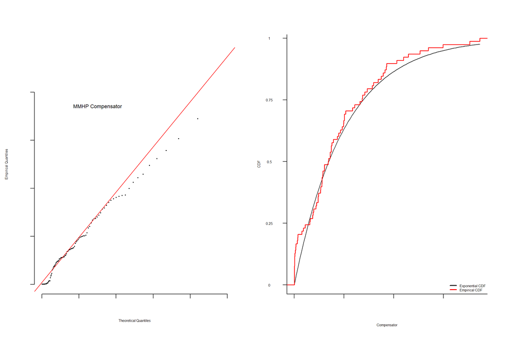

```r
axis_size = 0.5
title_size = 0.75
axis_lwd = 1
axis_tick = 0.8

p <- ppoints(100)

q <- quantile(MMHP_comp,p=p,na.rm=TRUE)

par(mfrow=c(1,2))

plot(qexp(p),q, xlab="",ylab="Empirical Quantiles",cex.lab=axis_size,
     pch=1,cex=0.25,col="Black",ylim=c(0,5),xlim=c(0,5), main = "", bty="n",
     yaxt ="n", xaxt = "n")
axis(1,at=seq(0,5,1),labels=FALSE,cex.lab=axis_tick,las=2,lwd=axis_lwd,lwd.ticks=1)
axis(2, at=seq(0,4,1),labels=FALSE,cex.lab = axis_tick,las=2,lwd=axis_lwd,lwd.ticks = 1)
text(x=2.5,y=-0.75,labels = "Theoretical Quantiles", cex = 0.5,srt = 0, xpd = TRUE )
#text(x = -0.5, y = 1.5, labels = "Empirical Quantiles", line = 0, cex = 0.5, srt = 0, xpd = TRUE)
text(x= 1.5, y = 3.7,labels="MMHP Compensator", cex=title_size, srt=0, xpd=TRUE)

qqline(q, distribution=qexp,col="Red", lty=1, lwd=1)


curve(pexp(x,1), min(MMHP_comp),max(MMHP_comp),col="Black",
      xlab="Compensator",ylab="CDF",cex.lab=axis_size, cex=axis_size,
      xaxt = "n", yaxt = "n", bty ="L")
axis(1,at=seq(0,4,1),labels=FALSE,cex.lab=axis_tick,las=2,lwd=axis_lwd,lwd.ticks=1)
axis(2, at=seq(0,1,0.25),labels=FALSE,cex.lab = axis_tick,las=2,lwd=axis_lwd,lwd.ticks = 1)
text(seq(0,4,1), y=-.25, labels=seq(0,3,1), cex=axis_size, srt=0, xpd=TRUE)
text(seq(0,1,0.25),x=-0.5,labels=seq(0,1,0.25),cex=axis_size,srt=0,xpd=TRUE)
plot(ecdf(MMHP_comp), add=TRUE, do.points=FALSE, col.01line = NULL, verticals=TRUE,col="Red", lwd=1.5, ylim=c(0,1))
legend("bottomright",c("Exponential CDF","Empirical CDF"),lty=1,lwd=2,col=c("Black","Red"),
       bty="n",cex=0.5)
```

These diagnostics indicate that our MMHP model is well suited to modeling this interaction data.

We can also fit the other methods described in the literature to this data and compare these models in terms of model fit.

We first compare to a simple Hawkes process.

```r
uniHawkesNegLogLik <- function(params=list(lambda0,alpha,beta), t) {
  lambda0 <- params[[1]]
  alpha <- params[[2]]
  beta <- params[[3]]
  n <- length(t)
  r <- rep(0,n)
  for(i in 2:n) {
    r[i] <- exp(-beta*(t[i]-t[i-1]))*(1+r[i-1])
  }
  loglik <- -t[n]*lambda0
  loglik <- loglik+alpha/beta*sum(exp(-beta*(t[n]-t))-1)
  if(any(lambda0+alpha*r<=0)){
    loglik<--1e+10
  }else{
    loglik <- loglik+sum(log(lambda0+alpha*r))
  }
  return(-loglik)
}


temp_t <- current_event_time
hawkes.par<-optim(par=rep(0.01,3), fn=uniHawkesNegLogLik,
                  t=temp_t, control = list(maxit = 1000) )

source("C:/Users/owenw/Documents/MMHP_Paper/lib/uniHawkes.R")

Lambda.test<-uniHawkesCompensator(lambda0=hawkes.par$par[1],alpha=hawkes.par$par[2],beta=hawkes.par$par[3],
                                  temp_t)
ks.test(Lambda.test,"pexp")
```

```
##
##  One-sample Kolmogorov-Smirnov test
##
## data:  Lambda.test
## D = 0.26536, p-value = 2.446e-05
## alternative hypothesis: two-sided
```

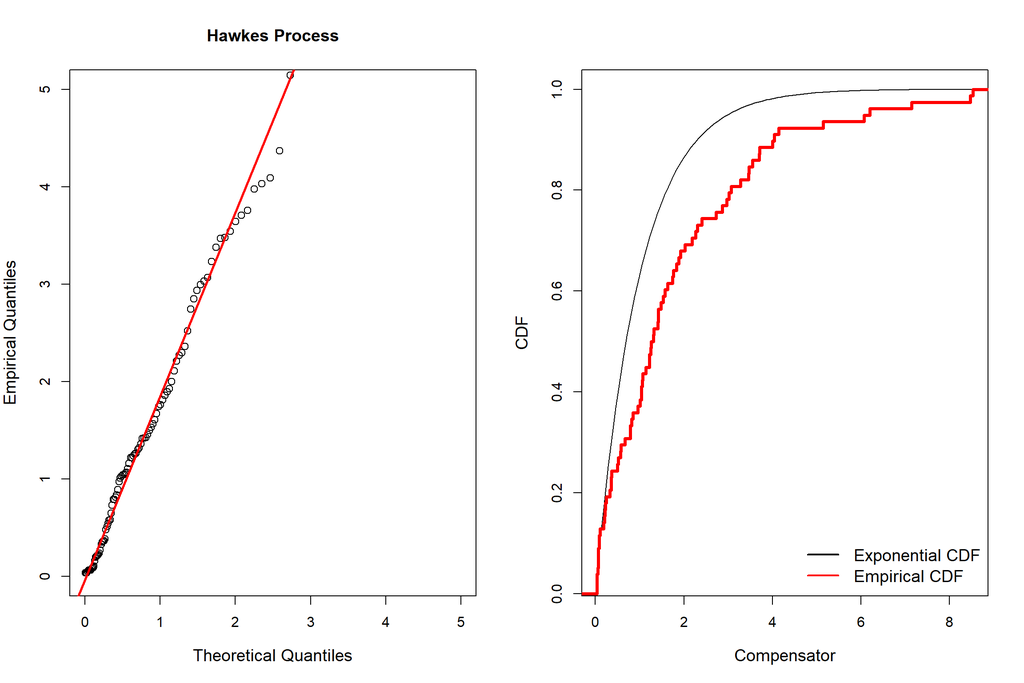

```r
par(mfrow=c(1,2))

p <- ppoints(100)    # 100 equally spaced points on (0,1), excluding endpoints
q <- quantile(Lambda.test,p=p,na.rm=TRUE) # percentiles of the sample distribution
plot(qexp(p),q, xlab="Theoretical Quantiles",ylab="Empirical Quantiles",cex.lab=1.2,
     pch=1,cex=1.1,col="Black",ylim=c(0,5),xlim=c(0,5), main = "Hawkes Process")
qqline(q, distribution=qexp,col="Red", lty=1, lwd=2.5)



curve(pexp(x,1), min(Lambda.test),max(Lambda.test),col="Black",
      xlab="Compensator",ylab="CDF",cex.lab=1.2)

plot(ecdf(Lambda.test), add=TRUE, do.points=FALSE, col.01line = NULL, verticals=TRUE,col="Red", lwd=3.5, ylim=c(0,1))
legend("bottomright",c("Exponential CDF","Empirical CDF"),lty=1,lwd=2,col=c("Black","Red"),
       bty="n",cex=1.2)
```

A Hawkes process is not able to capture the nature of this data.

Comparing to the MMPP model.

```r
# currently not working...
a = as.matrix(diff_times, nrow = 1, ncol = length(diff_times))

fit_mmpp <- stan("C:/Users/owenw/Documents/MMHP_Paper/lib/mmpp_continuous.stan",
                 data = list(N_til = 1,
                             max_Nm = length(time_vec),
                             Nm = as.array(length(time_vec)),
                             time_matrix= t(a),
                             max_interevent = as.array(max(diff_times))),
                 iter=3500, warmup = 1000, thin = 5,
                 chains=4)


sim_mmpp <- rstan::extract(fit_mmpp)

source("C:/Users/owenw/Documents/MMHP_Paper/lib/mmpp.R")
#source("C:/Users/owenw/Documents/MMHP_Analysis/lib/mmpp.R")

# new modified MMPP latent state Oct 3rd ####
param_mmpp_temp <- rep(list(),2000)
for(current_sim in 1:2000){
  param_mmpp_temp[[current_sim]] <- list(lambda0=sim_mmpp$lambda0[current_sim],
                                         q1=sim_mmpp$q1[current_sim],
                                         q2=sim_mmpp$q2[current_sim],
                                         alpha = 0,
                                         beta = 0.01,
                                         lambda1 = sim_mmpp$lambda0[current_sim]*(1+sim_mmpp$c[current_sim]))
}

param_mmpp <- rep(list(),2000)
for(current_sim in 1:2000){
  param_mmpp[[current_sim]] <- list(c=sim_mmpp$c[current_sim],
                               lambda0=sim_mmpp$lambda0[current_sim],
                               q1=sim_mmpp$q1[current_sim],
                               q2=sim_mmpp$q2[current_sim])
}

time_segment <- seq(0,termination_time,length.out=no_segments)

state_array_list_mmpp <- matrix(0,nrow=length(time_vec),ncol=2000)
interpolation_array_list_mmpp <- matrix(0,nrow=no_segments,ncol=2000)
count_flat <- c()

for(current_sim in 1:2000){
  ## latent states at event times
  viterbi_result <- myViterbiMMPP(events = time_vec, param = param_mmpp[[current_sim]],
                                  termination = termination_time)
  state_array_list_mmpp[,current_sim] <- viterbi_result$zt_v

  ## interpolation
  if(length(unique(viterbi_result$zt_v))==1){
    count_flat <- c(count_flat,current_sim)
    step_fun_est <- stepfun(max(time_vec),rep(2-unique(viterbi_result$zt_v),2))
  }else{
    # just update params
    latent_inter <- interpolateLatentTrajectory(params = param_mmpp_temp[[current_sim]], events = time_vec,
                                                zt = viterbi_result$zt_v,
                                                initial.state = viterbi_result$initial_state,
                                                termination.state = viterbi_result$termination_state,
                                                termination.time = termination_time )
    step_fun_est <- stepfun(latent_inter$x.hat,2-latent_inter$z.hat)
    # this means that interpolation_array is 1 for active and 0 for inactive.
    #interpolation_array_list[,current_sim] <- step_fun_est(time_segment)
  }
  interpolation_array_list_mmpp[,current_sim] <- step_fun_est(time_segment)
}
```

We can then plot the inferred latent state from this model.

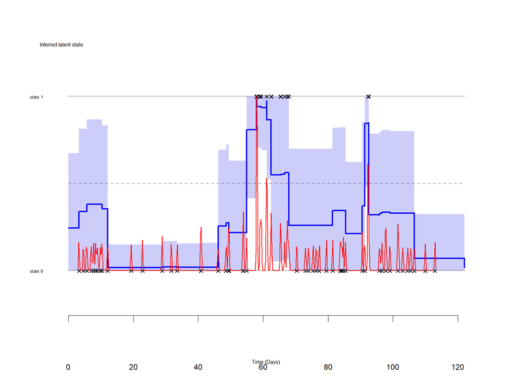

```r
ztv_mmpp <- t(ifelse(apply(state_array_list_mmpp,c(1),function(x) sum(x==1)) >1000,rep(1,2000),rep(2,2000)))
current_event_time = time_vec

time.segment <- seq(0,termination_time,length.out=10000)
time.segment.delta <- time.segment[2]-time.segment[1]

plot(0,0,xlim=c(-0.2,x_lim),ylim=c(-0.2,1.2), type="n",
     xlab="Time (Days)",ylab="",xaxt="n",yaxt="n",cex.lab=0.5,bty="n")
#title("(a) MMPP",line=1,cex.main=2)
axis(2,at=c(1,2),labels=FALSE,cex.lab=0.5,las=2,lwd=0,lwd.ticks=0)
axis(1,at=seq(0,x_lim,20),labels=FALSE,cex.lab=2,las=1,lwd=.3,lwd.ticks=0.5)
text(-9.5, y=c(0,1), labels=paste(c("state","state"),c(0,1)," "), cex=0.4, srt=0, xpd=TRUE)
text(-2, y=1.3, labels="Inferred latent state", cex=0.5, srt=0, xpd=TRUE)
text(seq(0,x_lim,20), y=-0.55, labels=seq(0,x_lim,20), cex=0.75, srt=0, xpd=TRUE)
segments(x0=0,x1=termination_time,y0=1,col="lightgrey",lwd=2)
segments(x0=0,x1=termination_time,y0=0,col="lightgrey",lwd=2)
segments(x0=0,x1=termination_time,y0=0.5,col="darkgrey",lwd=1,lty=2)
#segments(x0=clean_data$observation_change,y0=0,y1=1,col='red')



current_event_time <- time_vec


#prob <- apply(state_array_list_mmpp,1,function(x) sum(x==1)/2000)
points(current_event_time,2-ztv_mmpp,pch=4,col="black",lwd=1,cex=0.75)

## plot interpolated state
time_segment <- seq(0,termination_time,length.out=no_segments)#+delta.x
plot.mean <- apply(interpolation_array_list_mmpp,1,mean)
plot.sd <- apply(interpolation_array_list_mmpp,1,sd)
lines(plot.mean~time_segment,type="l",col="blue",lwd=2)
polygon(c(time_segment,rev(time_segment)),
        c(ifelse(plot.mean-plot.sd<0,rep(0,length(plot.mean)),plot.mean-plot.sd),
          rev(ifelse(plot.mean+plot.sd>1,rep(1,length(plot.mean)),plot.mean+plot.sd))),
        col=rgb(0,0,225,alpha=50,maxColorValue=255),border=FALSE)
#title("(a) MMPP",line=0.35,cex.main=0.5)

bw.used = 0.1
density.event=density(time_vec, bw=bw.used)
density.event$y=(density.event$y)/max(density.event$y)
lines(density.event, col=2)
```

Performing model evaluation, as before.

```r
par(mfrow=c(1,2))

lambda0_mean_mmpp <- mean(sim_mmpp$lambda0)
c_mean_mmpp <- mean(sim_mmpp$c)
q1_mean_mmpp <- mean(sim_mmpp$q1)
q2_mean_mmpp <- mean(sim_mmpp$q2)

params_mean_mmpp <- list(lambda0 = lambda0_mean_mmpp,
                         c = c_mean_mmpp,
                         q1 = q1_mean_mmpp,
                         q2 = q2_mean_mmpp)

prob <- apply(state_array_list_mmpp,1,function(x) sum(x==1)/2000)

MMPP_comp <- mmppCompensator(params =  params_mean_mmpp, t = c(0,time_vec),pzt = prob)

ks.test(MMPP_comp,"pexp")
```

```
##
##  One-sample Kolmogorov-Smirnov test
##
## data:  MMPP_comp
## D = 0.17743, p-value = 0.01473
## alternative hypothesis: two-sided
```

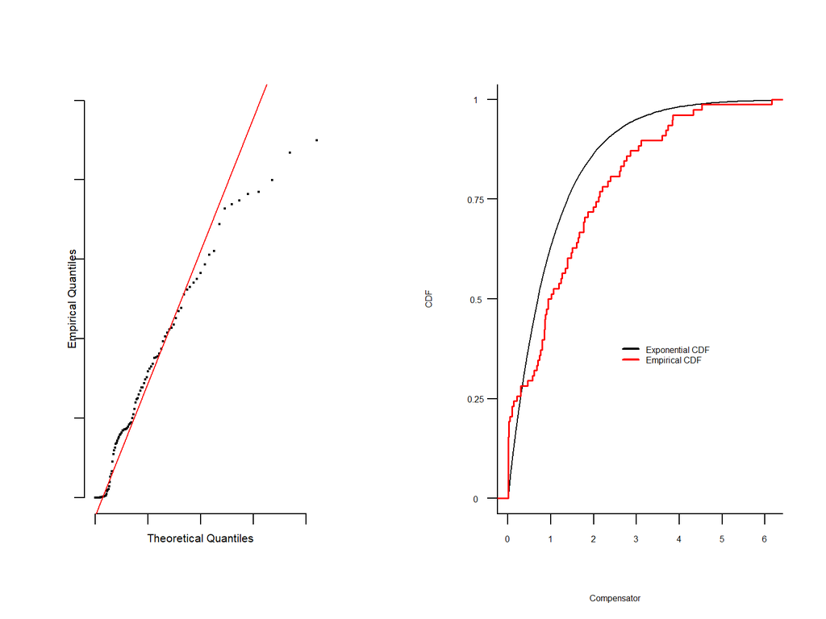

```r
p <- ppoints(100)

q <- quantile(MMPP_comp,p=p,na.rm=TRUE) # percentiles of the sample distribution



plot(qexp(p),q, xlab="",ylab="",cex.lab=axis_size,
     pch=1,cex=0.25,col="Black",ylim=c(0,5),xlim=c(0,5), main = "", bty="n",
     yaxt ="n", xaxt = "n")
axis(1,at=seq(0,4,1),labels=FALSE,cex.lab=axis_tick,las=2,lwd=axis_lwd,lwd.ticks=1)
axis(2, at=seq(0,5,1),labels=FALSE,cex.lab = axis_tick,las=2,lwd=axis_lwd,lwd.ticks = 1)
text(x=2,y=-0.5,labels = "Theoretical Quantiles", cex = 0.65,srt = 0, xpd = TRUE )
title(ylab="Empirical Quantiles", cex.lab =0.65,line = 0.25)
#text(x= 1.5, y = 5.5,labels="MMPP Compensator", cex=title_size, srt=0, xpd=TRUE)

qqline(q, distribution=qexp,col="Red", lty=1, lwd=1)

curve(pexp(x,1), min(MMPP_comp),max(MMPP_comp),col="Black",
      #xlab="Compensator",
      xlab = "",
      ylab="CDF",cex.lab=axis_size, cex=axis_size,
      xaxt = "n", yaxt = "n", bty ="L")
axis(1,at=seq(0,6,1),labels=FALSE,cex.lab=axis_tick,las=2,lwd=axis_lwd,lwd.ticks=1)
axis(2, at=seq(0,1,0.25),labels=FALSE,cex.lab = axis_tick,las=2,lwd=axis_lwd,lwd.ticks = 1)
text(seq(0,6,1), y=-.1, labels=seq(0,6,1), cex=axis_size, srt=0, xpd=TRUE)
text(seq(0,1,0.25),x=-0.75,labels=seq(0,1,0.25),cex=axis_size,srt=0,xpd=TRUE)
text(x=2.5,y=-0.25,labels = "Compensator", cex = 0.5,srt = 0, xpd = TRUE )
plot(ecdf(MMPP_comp), add=TRUE, do.points=FALSE, col.01line = NULL, verticals=TRUE,col="Red", lwd=1.5, ylim=c(0,1))
legend(x=2.5,y=0.4,c("Exponential CDF","Empirical CDF"),lty=1,lwd=2,col=c("Black","Red"),
       bty="n",cex=0.5)
```

This indicates that this model also struggles to capture the dynamics of these interactions.